# Binary Classification Model for Credit Card Default Using R Take 1

David Lowe

July 9, 2018

Template Credit: Adapted from a template made available by Dr. Jason Brownlee of Machine Learning Mastery. [http://machinelearningmastery.com/]

Dataset Used: Default of Credit Card Clients Data Set

Dataset ML Model: Binary classification with numerical attributes

Dataset Reference: https://archive.ics.uci.edu/ml/datasets/default+of+credit+card+clients

One potential source of performance benchmark: https://www.kaggle.com/uciml/default-of-credit-card-clients-dataset

INTRODUCTION: This dataset contains information on default payments, demographic factors, credit data, history of payment, and bill statements of credit card clients in Taiwan from April 2005 to September 2005.

The purpose of this project is to analyze predictions using various machine learning algorithms and to document the steps using a template. Working through machine learning problems from end-to-end requires a structured modeling approach. Working problems through a project template can also encourage us to think about the problem more critically, to challenge our assumptions, and to get proficient at all parts of a modeling project.

The project aims to touch on the following areas:

1. Document a predictive modeling problem end-to-end.
2. Explore data cleaning and transformation options
3. Explore non-ensemble and ensemble algorithms for baseline model performance
4. Explore algorithm tuning techniques for improving model performance

Any predictive modeling machine learning project genrally can be broken down into about six major tasks:

1. Prepare Problem
2. Summarize Data
3. Prepare Data
4. Model and Evaluate Algorithms
5. Improve Accuracy or Results
6. Finalize Model and Present Results

## 1. Prepare Problem

### 1.a) Load libraries

```r
library(caret)
```

```r
library(corrplot)
library(ROCR)
```

### 1.b) Load dataset

```r
startTimeScript <- proc.time()
entireDataset <- read.csv("default-of-credit-card-clients.csv", header= TRUE, stringsAsFactors = FALSE)

# Rename the class/target column to a standard label
colnames(entireDataset)[ncol(entireDataset)] <- "targetVar"

# Drop the Customer ID field as the label column has no relevance in the prediction exercise
entireDataset$CID <- NULL

# Use variable totCol to hold the number of columns in the dataframe
totCol <- ncol(entireDataset)
```

## 2. Summarize Data

To gain a better understanding of the data that we have on-hand, we will leverage a number of descriptive statistics and data visualization techniques. The plan is to use the results to consider new questions, review assumptions, and validate hypotheses that we can investigate later with specialized models.

### 2.a) Descriptive statistics

#### 2.a.i) Peek at the data itself.

```r
head(entireDataset)
```

```
##   LIMIT_BAL SEX EDUCATION MARRIAGE AGE PAY_0 PAY_2 PAY_3 PAY_4 PAY_5 PAY_6
## 1     20000   2         2        1  24     2     2    -1    -1    -2    -2
## 2    120000   2         2        2  26    -1     2     0     0     0     2
## 3     90000   2         2        2  34     0     0     0     0     0     0
## 4     50000   2         2        1  37     0     0     0     0     0     0
## 5     50000   1         2        1  57    -1     0    -1     0     0     0
## 6     50000   1         1        2  37     0     0     0     0     0     0
##   BILL_AMT1 BILL_AMT2 BILL_AMT3 BILL_AMT4 BILL_AMT5 BILL_AMT6 PAY_AMT1
## 1      3913      3102       689         0         0         0        0
## 2      2682      1725      2682      3272      3455      3261        0
## 3     29239     14027     13559     14331     14948     15549     1518
## 4     46990     48233     49291     28314     28959     29547     2000
## 5      8617      5670     35835     20940     19146     19131     2000
## 6     64400     57069     57608     19394     19619     20024     2500
##   PAY_AMT2 PAY_AMT3 PAY_AMT4 PAY_AMT5 PAY_AMT6 targetVar
## 1      689        0        0        0        0         1
## 2     1000     1000     1000        0     2000         1
## 3     1500     1000     1000     1000     5000         0
## 4     2019     1200     1100     1069     1000         0
## 5    36681    10000     9000      689      679         0
## 6     1815      657     1000     1000      800         0
```

#### 2.a.ii) Dimensions of the dataset.

```r
dim(entireDataset)
```

```
## [1] 30000    24
```

#### 2.a.iii) Types of the attributes.

```r
sapply(entireDataset, class)
```

```
## LIMIT_BAL       SEX EDUCATION  MARRIAGE       AGE     PAY_0     PAY_2
## "integer" "integer" "integer" "integer" "integer" "integer" "integer"
##     PAY_3     PAY_4     PAY_5     PAY_6 BILL_AMT1 BILL_AMT2 BILL_AMT3
## "integer" "integer" "integer" "integer" "integer" "integer" "integer"
## BILL_AMT4 BILL_AMT5 BILL_AMT6  PAY_AMT1  PAY_AMT2  PAY_AMT3  PAY_AMT4
## "integer" "integer" "integer" "integer" "integer" "integer" "integer"
##  PAY_AMT5  PAY_AMT6 targetVar
## "integer" "integer" "integer"
```

#### 2.a.iv) Statistical summary of all attributes.

```r
summary(entireDataset)
```

```
##    LIMIT_BAL            SEX          EDUCATION        MARRIAGE
##  Min.   :  10000   Min.   :1.000   Min.   :0.000   Min.   :0.000
##  1st Qu.:  50000   1st Qu.:1.000   1st Qu.:1.000   1st Qu.:1.000
##  Median : 140000   Median :2.000   Median :2.000   Median :2.000
##  Mean   : 167484   Mean   :1.604   Mean   :1.853   Mean   :1.552
##  3rd Qu.: 240000   3rd Qu.:2.000   3rd Qu.:2.000   3rd Qu.:2.000
##  Max.   :1000000   Max.   :2.000   Max.   :6.000   Max.   :3.000
##       AGE            PAY_0             PAY_2             PAY_3
##  Min.   :21.00   Min.   :-2.0000   Min.   :-2.0000   Min.   :-2.0000
##  1st Qu.:28.00   1st Qu.:-1.0000   1st Qu.:-1.0000   1st Qu.:-1.0000
##  Median :34.00   Median : 0.0000   Median : 0.0000   Median : 0.0000
##  Mean   :35.49   Mean   :-0.0167   Mean   :-0.1338   Mean   :-0.1662
##  3rd Qu.:41.00   3rd Qu.: 0.0000   3rd Qu.: 0.0000   3rd Qu.: 0.0000
##  Max.   :79.00   Max.   : 8.0000   Max.   : 8.0000   Max.   : 8.0000
##      PAY_4             PAY_5             PAY_6           BILL_AMT1
##  Min.   :-2.0000   Min.   :-2.0000   Min.   :-2.0000   Min.   :-165580
##  1st Qu.:-1.0000   1st Qu.:-1.0000   1st Qu.:-1.0000   1st Qu.:   3559
##  Median : 0.0000   Median : 0.0000   Median : 0.0000   Median :  22382
##  Mean   :-0.2207   Mean   :-0.2662   Mean   :-0.2911   Mean   :  51223
##  3rd Qu.: 0.0000   3rd Qu.: 0.0000   3rd Qu.: 0.0000   3rd Qu.:  67091
##  Max.   : 8.0000   Max.   : 8.0000   Max.   : 8.0000   Max.   : 964511
##    BILL_AMT2        BILL_AMT3         BILL_AMT4         BILL_AMT5
##  Min.   :-69777   Min.   :-157264   Min.   :-170000   Min.   :-81334
##  1st Qu.:  2985   1st Qu.:   2666   1st Qu.:   2327   1st Qu.:  1763
##  Median : 21200   Median :  20088   Median :  19052   Median : 18104
##  Mean   : 49179   Mean   :  47013   Mean   :  43263   Mean   : 40311
##  3rd Qu.: 64006   3rd Qu.:  60165   3rd Qu.:  54506   3rd Qu.: 50190
##  Max.   :983931   Max.   :1664089   Max.   : 891586   Max.   :927171
##    BILL_AMT6          PAY_AMT1         PAY_AMT2          PAY_AMT3
##  Min.   :-339603   Min.   :     0   Min.   :      0   Min.   :     0
##  1st Qu.:   1256   1st Qu.:  1000   1st Qu.:    833   1st Qu.:   390
##  Median :  17071   Median :  2100   Median :   2009   Median :  1800
##  Mean   :  38872   Mean   :  5664   Mean   :   5921   Mean   :  5226
##  3rd Qu.:  49198   3rd Qu.:  5006   3rd Qu.:   5000   3rd Qu.:  4505
##  Max.   : 961664   Max.   :873552   Max.   :1684259   Max.   :896040
##     PAY_AMT4         PAY_AMT5           PAY_AMT6          targetVar
##  Min.   :     0   Min.   :     0.0   Min.   :     0.0   Min.   :0.0000
##  1st Qu.:   296   1st Qu.:   252.5   1st Qu.:   117.8   1st Qu.:0.0000
##  Median :  1500   Median :  1500.0   Median :  1500.0   Median :0.0000
##  Mean   :  4826   Mean   :  4799.4   Mean   :  5215.5   Mean   :0.2212
##  3rd Qu.:  4013   3rd Qu.:  4031.5   3rd Qu.:  4000.0   3rd Qu.:0.0000
##  Max.   :621000   Max.   :426529.0   Max.   :528666.0   Max.   :1.0000
```

#### 2.a.v) Summarize the levels of the class attribute.

```r
entireDataset_x <- entireDataset[,1:(totCol-1)]
entireDataset_y <- entireDataset[,totCol]
cbind(freq=table(entireDataset_y), percentage=prop.table(table(entireDataset_y))*100)
```

```
##    freq percentage
## 0 23364      77.88
## 1  6636      22.12
```

#### 2.a.vi) Count missing values.

```r
sapply(entireDataset, function(x) sum(is.na(x)))
```

```
## LIMIT_BAL       SEX EDUCATION  MARRIAGE       AGE     PAY_0     PAY_2
##         0         0         0         0         0         0         0
##     PAY_3     PAY_4     PAY_5     PAY_6 BILL_AMT1 BILL_AMT2 BILL_AMT3
##         0         0         0         0         0         0         0
## BILL_AMT4 BILL_AMT5 BILL_AMT6  PAY_AMT1  PAY_AMT2  PAY_AMT3  PAY_AMT4
##         0         0         0         0         0         0         0
##  PAY_AMT5  PAY_AMT6 targetVar
##         0         0         0
```

### 2.b) Data visualizations

#### 2.b.i) Univariate plots to better understand each attribute.

```r
# Set up a variable for the total number of attribute columns (totAttr)
totAttr <- totCol-1
# Set up the number of row and columns for visualization display. dispRow * dispCol should be >= totAttr
dispCol <- 6
if (totAttr%%dispCol == 0) {
dispRow <- totAttr%/%dispCol
} else {
dispRow <- (totAttr%/%dispCol) + 1
}
cat("Will attempt to create graphics grid (col x row): ", dispCol, ' by ', dispRow)
```

```
## Will attempt to create graphics grid (col x row):  6  by  4
```

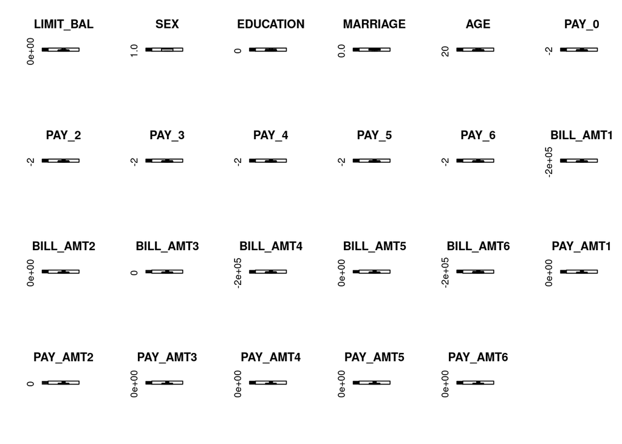

```r
# Boxplots for each attribute
par(mfrow=c(dispRow,dispCol))
for(i in 1:totAttr) {
    boxplot(entireDataset[,i], main=names(entireDataset)[i])
}
```

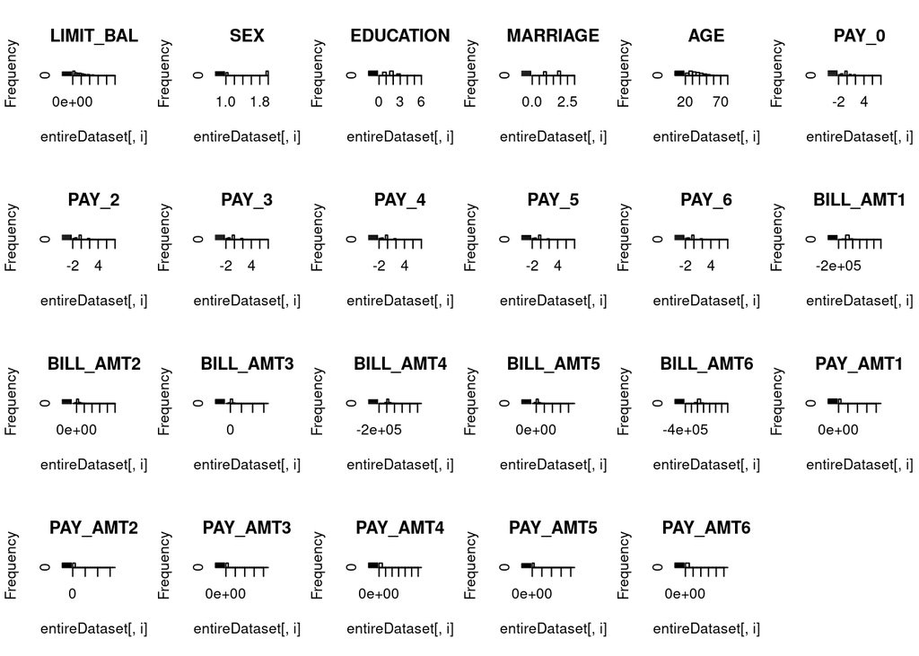

```r
# Histograms each attribute
par(mfrow=c(dispRow,dispCol))
for(i in 1:totAttr) {
    hist(entireDataset[,i], main=names(entireDataset)[i])
}
```

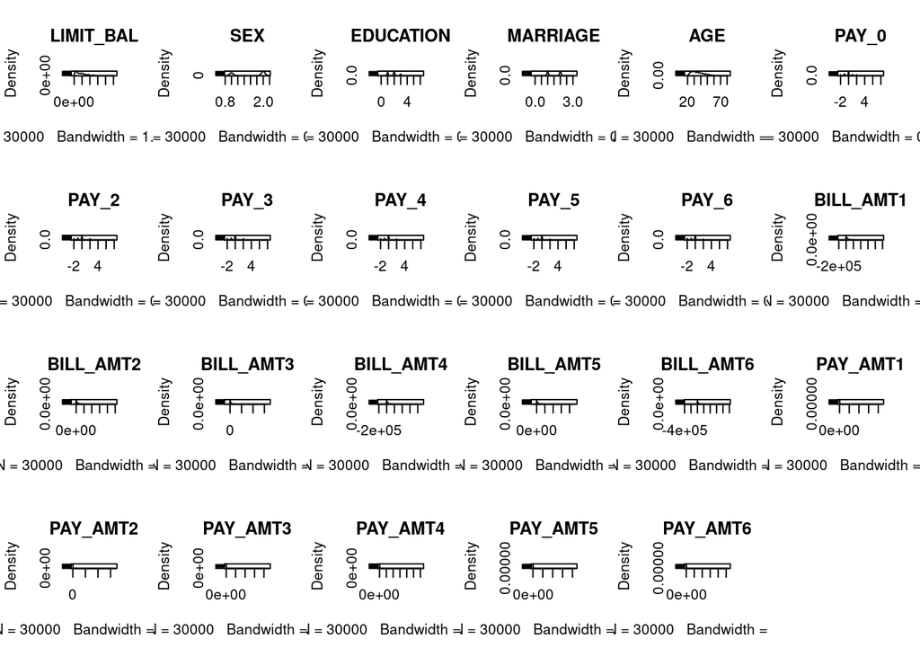

```r
# Density plot for each attribute
par(mfrow=c(dispRow,dispCol))
for(i in 1:totAttr) {
    plot(density(entireDataset[,i]), main=names(entireDataset)[i])
}
```

#### 2.b.ii) Multivariate plots to better understand the relationships between attributes

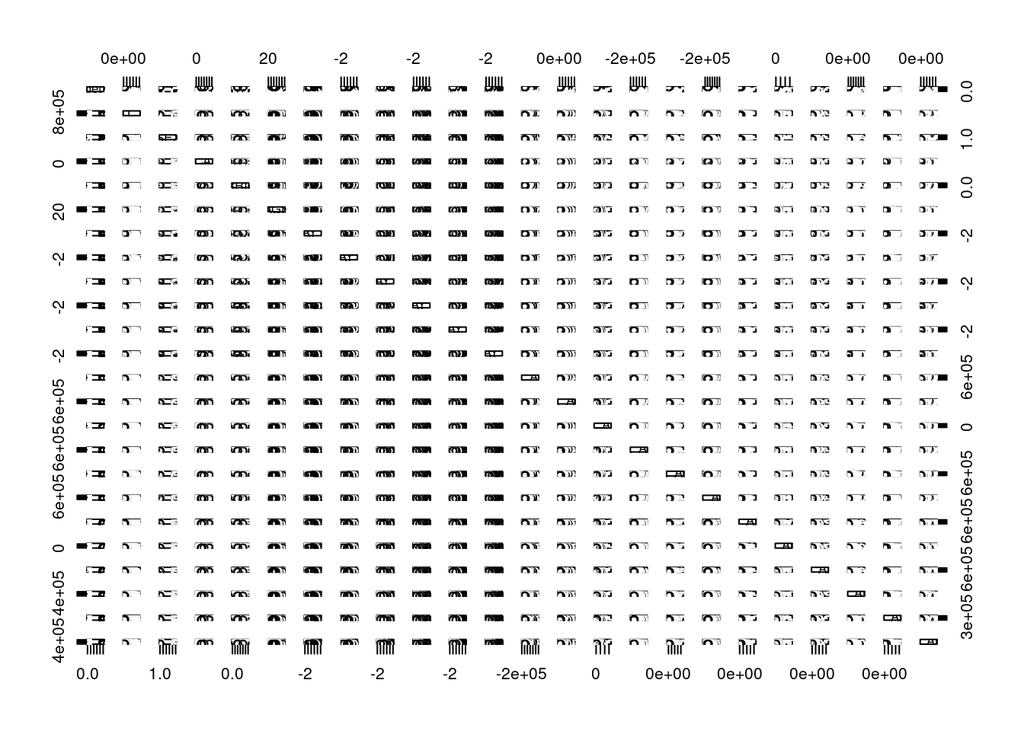

```r
# Scatterplot matrix colored by class
pairs(targetVar~., data=entireDataset, col=entireDataset$targetVar)
```

```r
# Box and whisker plots for each attribute by class
scales <- list(x=list(relation="free"), y=list(relation="free"))
featurePlot(x=entireDataset_x, y=entireDataset_y, plot="box", scales=scales)
```

[output not shown]

```r
# Density plots for each attribute by class value
featurePlot(x=entireDataset_x, y=entireDataset_y, plot="density", scales=scales)
```

[output not shown]

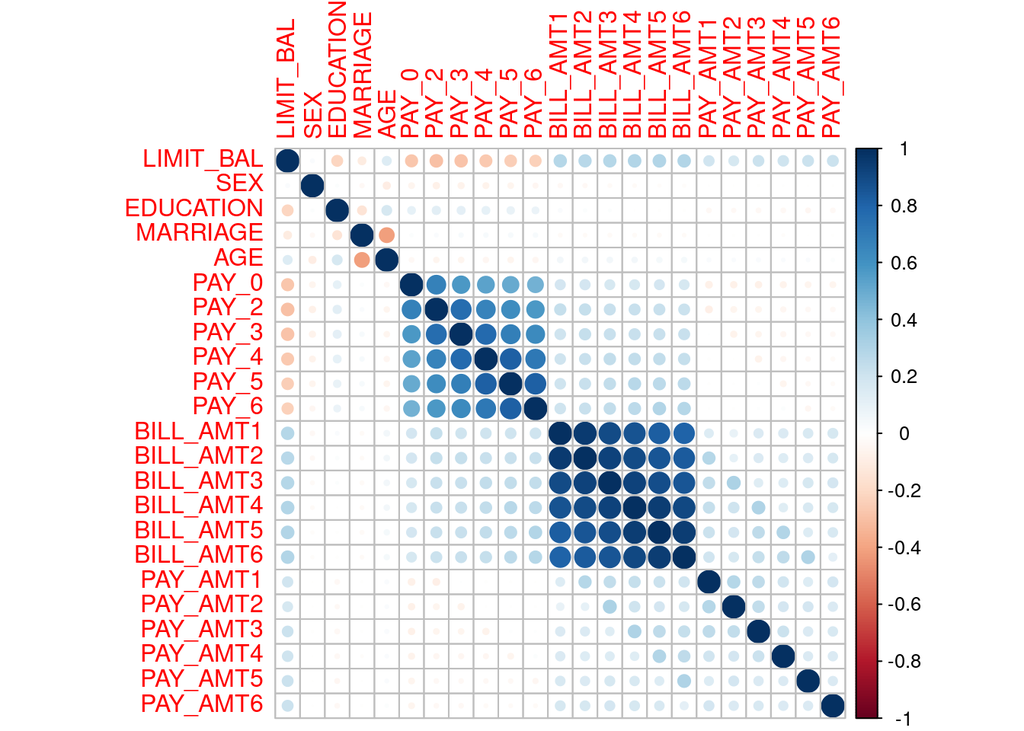

```r
# Correlation plot
correlations <- cor(entireDataset_x)
corrplot(correlations, method="circle")
```

## 3. Prepare Data

Some dataset may require additional preparation activities that will best exposes the structure of the problem and the relationships between the input attributes and the output variable. Some data-prep tasks might include:

- Cleaning data by removing duplicates, marking missing values and even imputing missing values.
- Feature selection where redundant features may be removed.
- Data transforms where attributes are scaled or redistributed in order to best expose the structure of the problem later to learning algorithms.

### 3.a) Data Cleaning

```r
# Correct the invalid values in the Education and Marital Status columns
entireDataset$EDUCATION[entireDataset$EDUCATION==0] <- 4
entireDataset$EDUCATION[entireDataset$EDUCATION==5] <- 4
entireDataset$EDUCATION[entireDataset$EDUCATION==6] <- 4
entireDataset$MARRIAGE[entireDataset$MARRIAGE==0] <- 3

# Impute missing values
#entireDataset$some_col <- with(entireDataset, impute(some_col, mean))
```

### 3.b) Feature Selection

```r
# Not applicable for this iteration of the project.
```

### 3.c) Data Transforms

```r
# Conver the integer variables to categorical variables as appropriate
entireDataset$SEX <- as.factor(entireDataset$SEX)
entireDataset$EDUCATION <- as.factor(entireDataset$EDUCATION)
entireDataset$MARRIAGE <- as.factor(entireDataset$MARRIAGE)
entireDataset$targetVar <- as.factor(entireDataset$targetVar)
```

### 3.d) Split-out training and validation datasets

We create a training dataset (variable name “training”) and a validation dataset (variable name “validation”).

```r
seedNum <- 888
set.seed(seedNum)

# Create a list of 70% of the rows in the original dataset we can use for training
training_index <- createDataPartition(entireDataset$targetVar, p=0.70, list=FALSE)

# Use 70% of data to training and testing the models
training <- entireDataset[training_index,]

# Select the remaining 30% of the data for validation
validation <- entireDataset[-training_index,]
```

```r
proc.time()-startTimeScript
```

```
##    user  system elapsed
## 651.148  28.110 687.336
```

## 4. Model and Evaluate Algorithms

After the data-prep, we next work on finding a workable model by evaluating a subset of machine learning algorithms that are good at exploiting the structure of the training. The typical evaluation tasks include:

- Defining test options such as cross validation and the evaluation metric to use.
- Spot checking a suite of linear and nonlinear machine learning algorithms.
- Comparing the estimated accuracy of algorithms.

For this project, we will evaluate one linear, three non-linear, and four ensemble algorithms:

Linear Algorithm: Logistic Regression

Non-Linear Algorithms: Decision Trees (CART), k-Nearest Neighbors, and Support Vector Machine

Ensemble Algorithms: Bagged CART, Random Forest, Adaboost, and Stochastic Gradient Boosting

The random number seed is reset before each run to ensure that the evaluation of each algorithm is performed using the same data splits. It ensures the results are directly comparable.

### 4.a) Set test options and evaluation metric

```r
# Run algorithms using 10-fold cross validation
control <- trainControl(method="repeatedcv", number=10, repeats=3)
metricTarget <- "Accuracy"
```

### 4.b) Generate models using linear algorithms

```r
# Logistic Regression (Classification)
startTimeModule <- proc.time()
set.seed(seedNum)
fit.glm <- train(targetVar~., data=training, method="glm", metric=metricTarget, trControl=control)
proc.time()-startTimeModule
```

```
##    user  system elapsed
##   8.435   4.127  12.716
```

### 4.c) Generate models using nonlinear algorithms

```r
# Decision Tree - CART (Regression/Classification)
startTimeModule <- proc.time()
set.seed(seedNum)
fit.cart <- train(targetVar~., data=training, method="rpart", metric=metricTarget, trControl=control)
proc.time()-startTimeModule
```

```
##    user  system elapsed
##  14.487   0.000  14.672
```

```r
# k-Nearest Neighbors (Regression/Classification)
startTimeModule <- proc.time()
set.seed(seedNum)
fit.knn <- train(targetVar~., data=training, method="knn", metric=metricTarget, trControl=control)
proc.time()-startTimeModule
```

```
##    user  system elapsed
## 112.865   0.000 114.242
```

```r
# Support Vector Machine (Regression/Classification)
startTimeModule <- proc.time()
set.seed(seedNum)
fit.svm <- train(targetVar~., data=training, method="svmRadial", metric=metricTarget, trControl=control)
proc.time()-startTimeModule
```

```
##     user   system  elapsed
## 3729.182    1.148 3775.178
```

### 4.d) Generate models using ensemble algorithms

In this section, we will explore the use and tuning of ensemble algorithms to see whether we can improve the results.

```r
# Bagged CART (Regression/Classification)
startTimeModule <- proc.time()
set.seed(seedNum)
fit.bagcart <- train(targetVar~., data=training, method="treebag", metric=metricTarget, trControl=control)
proc.time()-startTimeModule
```

```
##    user  system elapsed
## 367.730   0.130 372.176
```

```r
# Random Forest (Regression/Classification)
startTimeModule <- proc.time()
set.seed(seedNum)
fit.rf <- train(targetVar~., data=training, method="rf", metric=metricTarget, trControl=control)
proc.time()-startTimeModule
```

```
##     user   system  elapsed
## 4266.265    0.999 4318.463
```

```r
# AdaBoost (Classification)
startTimeModule <- proc.time()
set.seed(seedNum)
fit.ada <- train(targetVar~., data=training, method="ada", metric=metricTarget, trControl=control)
proc.time()-startTimeModule
```

```
##     user   system  elapsed
## 2430.850    0.861 2462.297
```

```r
# Stochastic Gradient Boosting (Regression/Classification)
startTimeModule <- proc.time()
set.seed(seedNum)
fit.gbm <- train(targetVar~., data=training, method="gbm", metric=metricTarget, trControl=control, verbose=F)
proc.time()-startTimeModule
```

```
##    user  system elapsed
## 244.722   0.084 247.682
```

### 4.e) Compare baseline algorithms

```r
results <- resamples(list(LR=fit.glm, CART=fit.cart, kNN=fit.knn, SVM=fit.svm, BagCART=fit.bagcart, RF=fit.rf, AdaBoost=fit.ada, GBM=fit.gbm))
summary(results)
```

```
##
## Call:
## summary.resamples(object = results)
##
## Models: LR, CART, kNN, SVM, BagCART, RF, AdaBoost, GBM
## Number of resamples: 30
##
## Accuracy
##               Min.   1st Qu.    Median      Mean   3rd Qu.      Max. NA's
## LR       0.7962875 0.8069967 0.8094783 0.8098504 0.8129762 0.8210376    0
## CART     0.8048548 0.8147619 0.8200857 0.8192786 0.8232774 0.8310328    0
## kNN      0.7533333 0.7628571 0.7648180 0.7650587 0.7686540 0.7751310    0
## SVM      0.8076190 0.8176407 0.8200428 0.8198500 0.8222196 0.8329367    0
## BagCART  0.7956170 0.8054297 0.8107143 0.8094060 0.8161370 0.8218199    0
## RF       0.8015231 0.8146957 0.8174679 0.8171517 0.8205403 0.8315088    0
## AdaBoost 0.8096145 0.8180302 0.8216244 0.8215164 0.8248245 0.8348406    0
## GBM      0.8105664 0.8176407 0.8216242 0.8219134 0.8265476 0.8338886    0
##
## Kappa
##                Min.    1st Qu.     Median      Mean   3rd Qu.      Max.
## LR       0.22220723 0.26306771 0.27449859 0.2759383 0.2866529 0.3315994
## CART     0.29083263 0.34329344 0.36617887 0.3645398 0.3818803 0.4253012
## kNN      0.06021049 0.09149778 0.09974776 0.1010674 0.1168766 0.1384840
## SVM      0.31840124 0.34760995 0.35746978 0.3580247 0.3666554 0.4137933
## BagCART  0.29697627 0.34230684 0.36067927 0.3559458 0.3781669 0.3980711
## RF       0.30614981 0.34407559 0.35691492 0.3559025 0.3683675 0.4211752
## AdaBoost 0.33750820 0.36302459 0.37612024 0.3770471 0.3885961 0.4321033
## GBM      0.34445150 0.36434246 0.38174124 0.3845685 0.3971390 0.4339930
##          NA's
## LR          0
## CART        0
## kNN         0
## SVM         0
## BagCART     0
## RF          0
## AdaBoost    0
## GBM         0
```

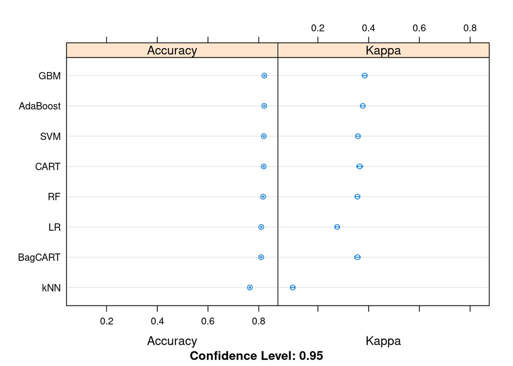

```r
dotplot(results)
```

## 5. Improve Accuracy or Results

After we achieve a short list of machine learning algorithms with good level of accuracy, we can leverage ways to improve the accuracy of the models.

Using the three best-perfoming algorithms from the previous section, we will Search for a combination of parameters for each algorithm that yields the best results.

### 5.a) Algorithm Tuning

Finally, we will tune the best-performing algorithms from each group further and see whether we can get more accuracy out of them.

```r
# Tuning algorithm #1 - AdaBoost
startTimeModule <- proc.time()
set.seed(seedNum)
grid <- expand.grid(iter = c(50, 100, 150), maxdepth = c(1, 2, 3), nu = c(0.05, 0.1, 0.2))
fit.final1 <- train(targetVar~., data=training, method="ada", metric=metricTarget, tuneGrid=grid, trControl=control)
print(fit.final1)
```

```
## Boosted Classification Trees
##
## 21001 samples
##    23 predictor
##     2 classes: '0', '1'
##
## No pre-processing
## Resampling: Cross-Validated (10 fold, repeated 3 times)
## Summary of sample sizes: 18902, 18901, 18901, 18902, 18900, 18900, ...
## Resampling results across tuning parameters:
##
##   nu    maxdepth  iter  Accuracy   Kappa
##   0.05  1          50   0.8158021  0.3210866
##   0.05  1         100   0.8159292  0.3263719
##   0.05  1         150   0.8155481  0.3280081
##   0.05  2          50   0.8216754  0.3742481
##   0.05  2         100   0.8208341  0.3680828
##   0.05  2         150   0.8194373  0.3599290
##   0.05  3          50   0.8215641  0.3770982
##   0.05  3         100   0.8217863  0.3780507
##   0.05  3         150   0.8215483  0.3765137
##   0.10  1          50   0.8153259  0.3242584
##   0.10  1         100   0.8159608  0.3325051
##   0.10  1         150   0.8161989  0.3355053
##   0.10  2          50   0.8202786  0.3655572
##   0.10  2         100   0.8193104  0.3597089
##   0.10  2         150   0.8194056  0.3614669
##   0.10  3          50   0.8215482  0.3770385
##   0.10  3         100   0.8213736  0.3762922
##   0.10  3         150   0.8212625  0.3759288
##   0.20  1          50   0.8157387  0.3314980
##   0.20  1         100   0.8161038  0.3355054
##   0.20  1         150   0.8161673  0.3378600
##   0.20  2          50   0.8195324  0.3598425
##   0.20  2         100   0.8199294  0.3643117
##   0.20  2         150   0.8199929  0.3656973
##   0.20  3          50   0.8213418  0.3765719
##   0.20  3         100   0.8212147  0.3769130
##   0.20  3         150   0.8215798  0.3787697
##
## Accuracy was used to select the optimal model using the largest value.
## The final values used for the model were iter = 100, maxdepth = 3 and nu
##  = 0.05.
```

```r
proc.time()-startTimeModule
```

```
##     user   system  elapsed
## 7384.629    3.048 7477.110
```

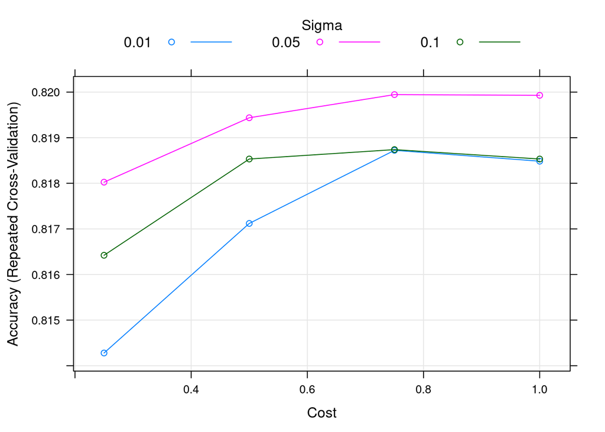

```r
# Tuning algorithm #2 - Support Vector Machine
startTimeModule <- proc.time()
set.seed(seedNum)
grid <- expand.grid(sigma = c(.01, .05, 0.1), C = c(0.25, 0.5, 0.75, 1))
fit.final2 <- train(targetVar~., data=training, method="svmRadial", metric=metricTarget, tuneGrid=grid, trControl=control)
plot(fit.final2)
```

```r
print(fit.final2)
```

```
## Support Vector Machines with Radial Basis Function Kernel
##
## 21001 samples
##    23 predictor
##     2 classes: '0', '1'
##
## No pre-processing
## Resampling: Cross-Validated (10 fold, repeated 3 times)
## Summary of sample sizes: 18902, 18901, 18901, 18902, 18900, 18900, ...
## Resampling results across tuning parameters:
##
##   sigma  C     Accuracy   Kappa
##   0.01   0.25  0.8142786  0.3280724
##   0.01   0.50  0.8171199  0.3438976
##   0.01   0.75  0.8187230  0.3483368
##   0.01   1.00  0.8184849  0.3473387
##   0.05   0.25  0.8180247  0.3492731
##   0.05   0.50  0.8194374  0.3549556
##   0.05   0.75  0.8199452  0.3580410
##   0.05   1.00  0.8199293  0.3589778
##   0.10   0.25  0.8164215  0.3372824
##   0.10   0.50  0.8185326  0.3489708
##   0.10   0.75  0.8187389  0.3523142
##   0.10   1.00  0.8185325  0.3532150
##
## Accuracy was used to select the optimal model using the largest value.
## The final values used for the model were sigma = 0.05 and C = 0.75.
```

```r
proc.time()-startTimeModule
```

```
##      user    system   elapsed
## 16111.502     6.624 16309.960
```

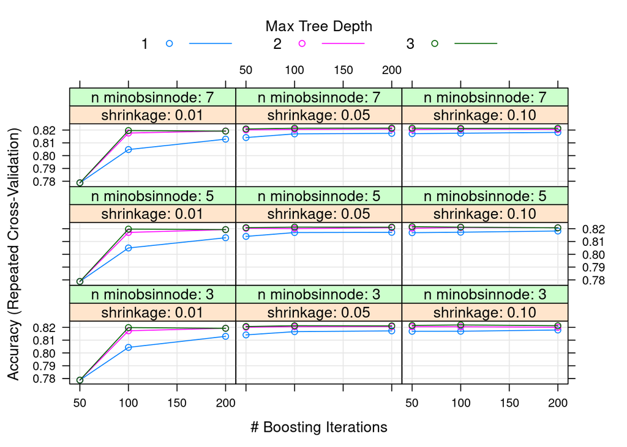

```r
# Tuning algorithm #3 - Stochastic Gradient Boosting
startTimeModule <- proc.time()
set.seed(seedNum)
grid <- expand.grid(.n.trees=c(50, 100, 200), .shrinkage=c(0.01, 0.05, 0.1), .interaction.depth=c(1, 2, 3), .n.minobsinnode=c(3, 5, 7))
fit.final3 <- train(targetVar~., data=training, method="gbm", metric=metricTarget, tuneGrid=grid, trControl=control, verbose=F)
plot(fit.final3)
```

```r
print(fit.final3)
```

```
## Stochastic Gradient Boosting
##
## 21001 samples
##    23 predictor
##     2 classes: '0', '1'
##
## No pre-processing
## Resampling: Cross-Validated (10 fold, repeated 3 times)
## Summary of sample sizes: 18902, 18901, 18901, 18902, 18900, 18900, ...
## Resampling results across tuning parameters:
##
##   shrinkage  interaction.depth  n.minobsinnode  n.trees  Accuracy
##   0.01       1                  3                50      0.7787725
##   0.01       1                  3               100      0.8043589
##   0.01       1                  3               200      0.8129929
##   0.01       1                  5                50      0.7787725
##   0.01       1                  5               100      0.8049459
##   0.01       1                  5               200      0.8129452
##   0.01       1                  7                50      0.7787725
##   0.01       1                  7               100      0.8047715
##   0.01       1                  7               200      0.8128977
##   0.01       2                  3                50      0.7787725
##   0.01       2                  3               100      0.8173417
##   0.01       2                  3               200      0.8193259
##   0.01       2                  5                50      0.7787725
##   0.01       2                  5               100      0.8171040
##   0.01       2                  5               200      0.8193101
##   0.01       2                  7                50      0.7787725
##   0.01       2                  7               100      0.8176752
##   0.01       2                  7               200      0.8193100
##   0.01       3                  3                50      0.7787725
##   0.01       3                  3               100      0.8198340
##   0.01       3                  3               200      0.8192624
##   0.01       3                  5                50      0.7787725
##   0.01       3                  5               100      0.8196912
##   0.01       3                  5               200      0.8192941
##   0.01       3                  7                50      0.7787725
##   0.01       3                  7               100      0.8196117
##   0.01       3                  7               200      0.8191672
##   0.05       1                  3                50      0.8141199
```

[output cut: 124 more lines]

```
##   0.3788002
##   0.3784164
##   0.3810782
##   0.3841943
##   0.3831754
##   0.3817083
##   0.3827749
##   0.3817422
##   0.3810396
##   0.3822120
##   0.3834301
##
## Accuracy was used to select the optimal model using the largest value.
## The final values used for the model were n.trees = 100,
##  interaction.depth = 3, shrinkage = 0.1 and n.minobsinnode = 3.
```

```r
proc.time()-startTimeModule
```

```
##     user   system  elapsed
## 2868.662    1.049 2903.865
```

### 5.d) Compare Algorithms After Tuning

```r
results <- resamples(list(ADA=fit.final1, SVM=fit.final2, GBM=fit.final3))
summary(results)
```

```
##
## Call:
## summary.resamples(object = results)
##
## Models: ADA, SVM, GBM
## Number of resamples: 30
##
## Accuracy
##          Min.   1st Qu.    Median      Mean   3rd Qu.      Max. NA's
## ADA 0.8091385 0.8187552 0.8220581 0.8217863 0.8240686 0.8348406    0
## SVM 0.8071429 0.8176190 0.8204762 0.8199452 0.8223253 0.8338886    0
## GBM 0.8105664 0.8183333 0.8214286 0.8218975 0.8241457 0.8338886    0
##
## Kappa
##          Min.   1st Qu.    Median      Mean   3rd Qu.      Max. NA's
## ADA 0.3376861 0.3708031 0.3763850 0.3780507 0.3858376 0.4331375    0
## SVM 0.3168574 0.3487201 0.3565406 0.3580410 0.3658345 0.4171335    0
## GBM 0.3456529 0.3694322 0.3795846 0.3841943 0.3941706 0.4329679    0
```

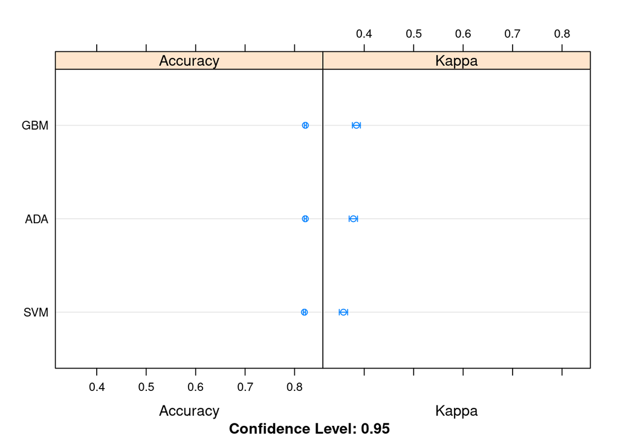

```r
dotplot(results)
```

## 6. Finalize Model and Present Results

Once we have narrow down to a model that we believe can make accurate predictions on unseen data, we are ready to finalize it. Finalizing a model may involve sub-tasks such as:

- Using an optimal model tuned to make predictions on unseen data.
- Creating a standalone model using the tuned parameters
- Saving an optimal model to file for later use.

### 6.a) Predictions on validation dataset

```r
predictions <- predict(fit.final3, newdata=validation)
confusionMatrix(predictions, validation$targetVar)
```

```
## Confusion Matrix and Statistics
##
##           Reference
## Prediction    0    1
##          0 6643 1259
##          1  366  731
##
##                Accuracy : 0.8194
##                  95% CI : (0.8113, 0.8273)
##     No Information Rate : 0.7789
##     P-Value [Acc > NIR] : < 2.2e-16
##
##                   Kappa : 0.3754
##  Mcnemar's Test P-Value : < 2.2e-16
##
##             Sensitivity : 0.9478
##             Specificity : 0.3673
##          Pos Pred Value : 0.8407
##          Neg Pred Value : 0.6664
##              Prevalence : 0.7789
##          Detection Rate : 0.7382
##    Detection Prevalence : 0.8781
##       Balanced Accuracy : 0.6576
##
##        'Positive' Class : 0
##
```

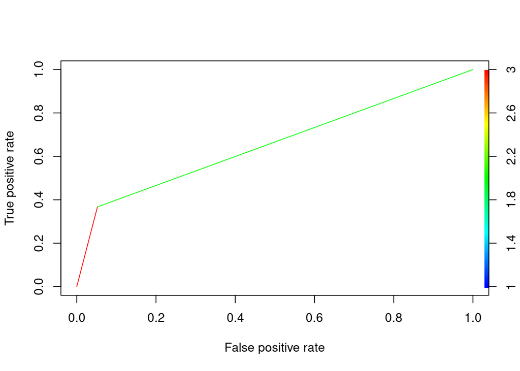

```r
pred <- prediction(as.numeric(predictions), as.numeric(validation$targetVar))
perf <- performance(pred, measure = "tpr", x.measure = "fpr")
plot(perf, colorize=TRUE)
```

```r
auc <- performance(pred, measure = "auc")
auc <- auc@y.values[[1]]
auc
```

```
## [1] 0.6575591
```

### 6.b) Create standalone model on entire training dataset

```r
startTimeModule <- proc.time()
set.seed(seedNum)
grid <- expand.grid(.n.trees=100, .shrinkage=0.1, .interaction.depth=3, .n.minobsinnode=3)
finalModel <- train(targetVar~., data=entireDataset, method="gbm", metric=metricTarget, tuneGrid=grid, trControl=control, verbose=F)
print(finalModel)
```

```
## Stochastic Gradient Boosting
##
## 30000 samples
##    23 predictor
##     2 classes: '0', '1'
##
## No pre-processing
## Resampling: Cross-Validated (10 fold, repeated 3 times)
## Summary of sample sizes: 27000, 27000, 27000, 27001, 27000, 26999, ...
## Resampling results:
##
##   Accuracy   Kappa
##   0.8208886  0.3797663
##
## Tuning parameter 'n.trees' was held constant at a value of 100
##  3
## Tuning parameter 'shrinkage' was held constant at a value of 0.1
##
## Tuning parameter 'n.minobsinnode' was held constant at a value of 3
```

```r
proc.time()-startTimeModule
```

```
##    user  system elapsed
## 112.888   0.048 114.237
```

### 6.c) Save model for later use

```r
#saveRDS(finalModel, "./finalModel_BinaryClass.rds")
```

```r
proc.time()-startTimeScript
```

```
##      user    system   elapsed
## 38309.492    46.276 38816.207
```